# clust_stand_err_final

### 7.0.1 making sure my pubertal stage and sleep satisfaction association holds using this type of model (adjusting for clustered IDs)

```r
m2 <- lm(scale(DailySleep_satisfaction) ~  tanner_average_for_mw_z + tanner_age_for_mw_z, data = mw_merge_cent)
# also holds controlling for asq
m2cov <- lm(scale(DailySleep_satisfaction) ~  scale(asq_total_mw) + tanner_average_for_mw_z + tanner_age_for_mw_z, data = mw_merge_cent)
summary(m2cov)
```

```
##
## Call:
## lm(formula = scale(DailySleep_satisfaction) ~ scale(asq_total_mw) +
##     tanner_average_for_mw_z + tanner_age_for_mw_z, data = mw_merge_cent)
##
## Residuals:
##    Min     1Q Median     3Q    Max
## -2.696 -0.675  0.154  0.756  2.157
##
## Coefficients:
##                         Estimate Std. Error t value Pr(>|t|)
## (Intercept)             -0.05811    0.03729  -1.558    0.120
## scale(asq_total_mw)     -0.19963    0.03483  -5.732 1.42e-08 ***
## tanner_average_for_mw_z -0.18367    0.03774  -4.867 1.37e-06 ***
## tanner_age_for_mw_z     -0.04369    0.04952  -0.882    0.378
## ---
## Signif. codes:  0 '***' 0.001 '**' 0.01 '*' 0.05 '.' 0.1 ' ' 1
##
## Residual standard error: 0.9915 on 791 degrees of freedom
##   (2302 observations deleted due to missingness)
## Multiple R-squared:  0.08101,    Adjusted R-squared:  0.07752
## F-statistic: 23.24 on 3 and 791 DF,  p-value: 2.001e-14
```

```r
car::vif(m2)
```

```
## tanner_average_for_mw_z     tanner_age_for_mw_z
##                1.247626                1.247626
```

```r
m2_c <- coeftest(m2, vcov = vcovCL, cluster = ~ELS_ID)
m2_c
```

```
##
## t test of coefficients:
##
##                           Estimate Std. Error t value Pr(>|t|)
## (Intercept)             -0.0053692  0.0699852 -0.0767 0.938863
## tanner_average_for_mw_z -0.2034481  0.0737134 -2.7600 0.005891 **
## tanner_age_for_mw_z      0.0543854  0.0664470  0.8185 0.413288
## ---
## Signif. codes:  0 '***' 0.001 '**' 0.01 '*' 0.05 '.' 0.1 ' ' 1
```

```r
confint(m2_c)
```

```
##                               2.5 %     97.5 %
## (Intercept)             -0.14271114  0.1319727
## tanner_average_for_mw_z -0.34810651 -0.0587896
## tanner_age_for_mw_z     -0.07601312  0.1847839
```

```r
m2_cov <- coeftest(m2cov, vcov = vcovCL, cluster = ~ELS_ID)
m2_cov
```

```
##
## t test of coefficients:
##
##                          Estimate Std. Error t value Pr(>|t|)
## (Intercept)             -0.058114   0.080780 -0.7194 0.472098
## scale(asq_total_mw)     -0.199628   0.068435 -2.9170 0.003634 **
## tanner_average_for_mw_z -0.183670   0.072995 -2.5162 0.012060 *
## tanner_age_for_mw_z     -0.043686   0.086095 -0.5074 0.612004
## ---
## Signif. codes:  0 '***' 0.001 '**' 0.01 '*' 0.05 '.' 0.1 ' ' 1
```

```r
confint(m2_cov)
```

```
##                              2.5 %      97.5 %
## (Intercept)             -0.2166832  0.10045443
## scale(asq_total_mw)     -0.3339638 -0.06529135
## tanner_average_for_mw_z -0.3269580 -0.04038289
## tanner_age_for_mw_z     -0.2126868  0.12531511
```

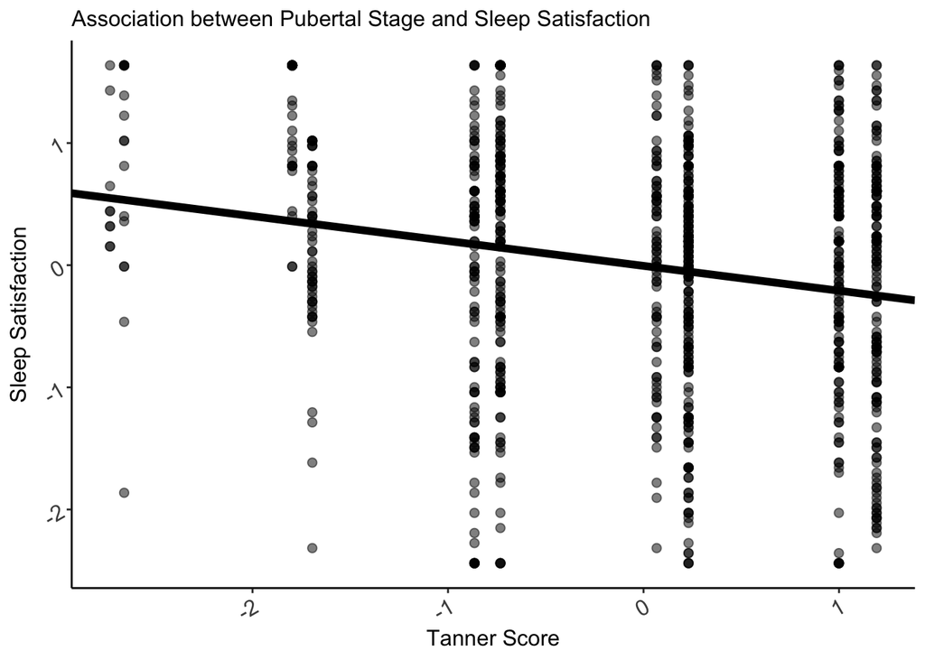

```r
tanint2 <- summary(m2)$coefficients[1,1] # fine to extract from the OLS bc reg coefs don't change (just the SEs)
tanslp2 <- summary(m2)$coefficients[2,1]

mw_merge_cent %>%
  ggplot(
    aes(
      x = tanner_average_for_mw_z,
      y = scale(DailySleep_satisfaction)
    )
  ) +
  geom_point(size = 2, alpha = .5) +
  geom_abline(
    intercept = tanint2,
    slope = tanslp2,
    size=2
    ) +
  theme_classic() +
  labs(
    x = "Tanner Score",
    y = "Sleep Satisfaction",
    title = "Association between Pubertal Stage and Sleep Satisfaction"
  ) +
  theme(
    axis.text = element_text(size = 12, angle = 30, hjust = 1),
    axis.title = element_text(size = 12),
    plot.title = element_text(size = 12)
  )
```

```r
ggsave("tan_and_sleep_crse.png", width = 6, height =6)
# MLM
level2modds<- lmer(scale(DailySleep_satisfaction)  ~  tanner_average_for_mw_z + scale(asq_total_mw) + tanner_age_for_mw_z + day_id + (1| ELS_ID), na.action = na.exclude, data = mw_merge_cent)
tab_model(level2modds, p.val = "kr")
```

|  | scale(Daily Sleep satisfaction) |  |  |
| --- | --- | --- | --- |
| Predictors | Estimates | CI | p |
| (Intercept) | -0.05 | -0.22 – 0.13 | 0.592 |
| tanner_average_for_mw_z | -0.18 | -0.33 – -0.03 | **0.018** |
| asq_total_mw | -0.20 | -0.34 – -0.06 | **0.005** |
| tanner_age_for_mw_z | -0.06 | -0.25 – 0.14 | 0.567 |
| day_id | 0.00 | -0.01 – 0.02 | 0.958 |
| Random Effects |  |  |  |
| σ<sup>2</sup> | 0.62 |  |  |
| τ<sub>00</sub> <sub>ELS_ID</sub> | 0.37 |  |  |
| ICC | 0.37 |  |  |
| N <sub>ELS_ID</sub> | 89 |  |  |
| Observations | 795 |  |  |
| Marginal R<sup>2</sup> / Conditional R<sup>2</sup> | 0.083 / 0.426 |  |  |

```r
# aligns with cr-se
```

## 7.1 testing if postive and negative affect are associated with sleep sat controlling for perceived stress (and then also tanner)

```r
m3 <- lm(scale(DailySleep_satisfaction) ~ scale(asq_total_mw) + scale(neg_total_sqrt) + scale(pos_total), data = mw_merge_cent)
summary(m3)
```

```
##
## Call:
## lm(formula = scale(DailySleep_satisfaction) ~ scale(asq_total_mw) +
##     scale(neg_total_sqrt) + scale(pos_total), data = mw_merge_cent)
##
## Residuals:
##     Min      1Q  Median      3Q     Max
## -3.4937 -0.5983  0.1803  0.6490  2.1636
##
## Coefficients:
##                       Estimate Std. Error t value Pr(>|t|)
## (Intercept)            0.07250    0.03552   2.041   0.0416 *
## scale(asq_total_mw)   -0.04010    0.03924  -1.022   0.3071
## scale(neg_total_sqrt) -0.23960    0.03969  -6.037 2.41e-09 ***
## scale(pos_total)       0.25769    0.03483   7.398 3.52e-13 ***
## ---
## Signif. codes:  0 '***' 0.001 '**' 0.01 '*' 0.05 '.' 0.1 ' ' 1
##
## Residual standard error: 0.9466 on 791 degrees of freedom
##   (2302 observations deleted due to missingness)
## Multiple R-squared:  0.1622, Adjusted R-squared:  0.1591
## F-statistic: 51.06 on 3 and 791 DF,  p-value: < 2.2e-16
```

```r
car::vif(m3)
```

```
##   scale(asq_total_mw) scale(neg_total_sqrt)      scale(pos_total)
##              1.409744              1.440971              1.072179
```

```r
m3c <- coeftest(m3, vcov = vcovCL, cluster = ~ELS_ID)
confint(m3c)
```

```
##                             2.5 %     97.5 %
## (Intercept)           -0.05511152  0.2001027
## scale(asq_total_mw)   -0.18756904  0.1073594
## scale(neg_total_sqrt) -0.35350680 -0.1256932
## scale(pos_total)       0.13491695  0.3804580
```

```r
m3cov <- lm(scale(DailySleep_satisfaction) ~ scale(asq_total_mw) + scale(neg_total_sqrt) + scale(pos_total) +  tanner_average_for_mw_z +  tanner_age_for_mw_z, data = mw_merge_cent)
summary(m3cov)
```

```
##
## Call:
## lm(formula = scale(DailySleep_satisfaction) ~ scale(asq_total_mw) +
##     scale(neg_total_sqrt) + scale(pos_total) + tanner_average_for_mw_z +
##     tanner_age_for_mw_z, data = mw_merge_cent)
##
## Residuals:
##     Min      1Q  Median      3Q     Max
## -3.2645 -0.5999  0.1485  0.6478  1.9414
##
## Coefficients:
##                         Estimate Std. Error t value Pr(>|t|)
## (Intercept)              0.04402    0.03771   1.167    0.243
## scale(asq_total_mw)     -0.04073    0.03894  -1.046    0.296
## scale(neg_total_sqrt)   -0.21655    0.03978  -5.443 6.98e-08 ***
## scale(pos_total)         0.24879    0.03487   7.135 2.20e-12 ***
## tanner_average_for_mw_z -0.14304    0.03613  -3.959 8.20e-05 ***
## tanner_age_for_mw_z     -0.01122    0.04732  -0.237    0.813
## ---
## Signif. codes:  0 '***' 0.001 '**' 0.01 '*' 0.05 '.' 0.1 ' ' 1
##
## Residual standard error: 0.9372 on 789 degrees of freedom
##   (2302 observations deleted due to missingness)
## Multiple R-squared:  0.1808, Adjusted R-squared:  0.1757
## F-statistic: 34.84 on 5 and 789 DF,  p-value: < 2.2e-16
```

```r
car::vif(m3cov)
```

```
##     scale(asq_total_mw)   scale(neg_total_sqrt)        scale(pos_total)
##                1.415971                1.477022                1.096285
## tanner_average_for_mw_z     tanner_age_for_mw_z
##                1.138503                1.133077
```

```r
m3cov_c <- coeftest(m3cov, vcov = vcovCL, cluster = ~ELS_ID)
confint(m3cov_c)
```

```
##                               2.5 %      97.5 %
## (Intercept)             -0.09220951  0.18025893
## scale(asq_total_mw)     -0.18241818  0.10095176
## scale(neg_total_sqrt)   -0.32437794 -0.10872189
## scale(pos_total)         0.13557673  0.36200526
## tanner_average_for_mw_z -0.27023437 -0.01583931
## tanner_age_for_mw_z     -0.16646144  0.14402417
```

```r
negint3 <- summary(m3)$coefficients[1,1] # fine to extract from the OLS bc reg coefs don't change (just the SEs)
negslp3 <- summary(m3)$coefficients[3,1]
na_sleep <- mw_merge_cent %>%
  ggplot(
    aes(
      x = scale(neg_total_sqrt),
      y = scale(DailySleep_satisfaction)
    )
  ) +
  geom_point(size = 2, alpha = .5, color = "black") +
  geom_abline(
    intercept = negint3,
    slope = negslp3,
    size=2,
    color = "black"
    ) +
  theme_classic() +
  labs(
    x = "Negative Affect",
    y = "Sleep Satisfaction"
  ) +
  theme(
    axis.text = element_text(size = 10, angle = 30, hjust = 1),
    axis.title = element_text(size = 12),
    plot.title = element_text(size = 12)
  )

posint3 <- summary(m3)$coefficients[1,1] # fine to extract from the OLS bc reg coefs don't change (just the SEs)
posslp3 <- summary(m3)$coefficients[4,1]
pa_sleep <- mw_merge_cent %>%
  ggplot(
    aes(
      x = scale(pos_total),
      y = scale(DailySleep_satisfaction)
    )
  ) +
  geom_point(size = 2, alpha = .5, color = "black") +
  geom_abline(
    intercept = posint3,
    slope = posslp3,
    size=2,
    color = "black"
    ) +
  theme_classic() +
  labs(
    x = "Positive Affect",
    y = "Sleep Satisfaction"
  ) +
  theme(
    axis.text = element_text(size = 10, angle = 30, hjust = 1),
    axis.title = element_text(size = 12),
    plot.title = element_text(size = 12)
  )
library(gridExtra)
library(cowplot)
mwsleepaffect <-
  cowplot::plot_grid(
    na_sleep,
    pa_sleep,
    labels = c('A', 'B'),
    label_size = 10
    )
ggsave("sleep_NA_PA_crse.png", mwsleepaffect, width = 9, height = 5)
# MLM
level3modds<- lmer(scale(DailySleep_satisfaction)  ~  tanner_average_for_mw_z + scale(asq_total_mw) + scale(neg_total_sqrt) + scale(pos_total) + day_id + (1| ELS_ID), na.action = na.exclude, data = mw_merge_cent)
tab_model(level3modds, p.val = "kr")
```

|  | scale(Daily Sleep satisfaction) |  |  |
| --- | --- | --- | --- |
| Predictors | Estimates | CI | p |
| (Intercept) | 0.03 | -0.13 – 0.19 | 0.704 |
| tanner_average_for_mw_z | -0.14 | -0.28 – -0.01 | **0.039** |
| asq_total_mw | -0.04 | -0.18 – 0.09 | 0.530 |
| neg_total_sqrt | -0.24 | -0.32 – -0.15 | **<0.001** |
| pos_total | 0.19 | 0.11 – 0.26 | **<0.001** |
| day_id | 0.00 | -0.01 – 0.02 | 0.888 |
| Random Effects |  |  |  |
| σ<sup>2</sup> | 0.58 |  |  |
| τ<sub>00</sub> <sub>ELS_ID</sub> | 0.31 |  |  |
| ICC | 0.35 |  |  |
| N <sub>ELS_ID</sub> | 89 |  |  |
| Observations | 795 |  |  |
| Marginal R<sup>2</sup> / Conditional R<sup>2</sup> | 0.161 / 0.455 |  |  |

```r
# aligns with cr-se
```

## 7.2 testing if postive and negative affect are associated with sleep duration controlling for perceived stress (and then also tanner)

```r
m4 <- lm(scale(DailySleep_hrs_rec) ~ scale(sumsev_type) + scale(neg_total_sqrt) + scale(pos_total), data = mw_merge_cent)
summary(m4)
```

```
##
## Call:
## lm(formula = scale(DailySleep_hrs_rec) ~ scale(sumsev_type) +
##     scale(neg_total_sqrt) + scale(pos_total), data = mw_merge_cent)
##
## Residuals:
##     Min      1Q  Median      3Q     Max
## -2.3413 -0.5520  0.2295  0.6811  1.9683
##
## Coefficients:
##                        Estimate Std. Error t value Pr(>|t|)
## (Intercept)            0.003541   0.033178   0.107   0.9150
## scale(sumsev_type)    -0.169507   0.032213  -5.262 1.76e-07 ***
## scale(neg_total_sqrt) -0.071294   0.033400  -2.135   0.0331 *
## scale(pos_total)       0.050326   0.032601   1.544   0.1230
## ---
## Signif. codes:  0 '***' 0.001 '**' 0.01 '*' 0.05 '.' 0.1 ' ' 1
##
## Residual standard error: 0.9853 on 943 degrees of freedom
##   (2150 observations deleted due to missingness)
## Multiple R-squared:  0.03842,    Adjusted R-squared:  0.03536
## F-statistic: 12.56 on 3 and 943 DF,  p-value: 4.693e-08
```

```r
car::vif(m4)
```

```
##    scale(sumsev_type) scale(neg_total_sqrt)      scale(pos_total)
##              1.008488              1.069544              1.074647
```

```r
m4c <- coeftest(m4, vcov = vcovCL, cluster = ~ELS_ID)
confint(m4c)
```

```
##                             2.5 %      97.5 %
## (Intercept)           -0.13351015  0.14059310
## scale(sumsev_type)    -0.27280217 -0.06621182
## scale(neg_total_sqrt) -0.19083182  0.04824341
## scale(pos_total)      -0.06707236  0.16772349
```

# 8 Hypothesis 2: Higher Tanner stage is associated with higher negative affect and lower positive affect

testing for potential covariates

```r
c1 <- lm(scale(neg_total_sqrt) ~ bmi_at_mw_z, data = mw_merge_cent)
c1_c <- coeftest(c1, vcov = vcovCL, cluster = ~ELS_ID) # nope
c1_c
```

```
##
## t test of coefficients:
##
##               Estimate Std. Error t value Pr(>|t|)
## (Intercept) -0.0043486  0.0801445 -0.0543   0.9567
## bmi_at_mw_z -0.0305115  0.0733740 -0.4158   0.6776
```

```r
c2 <- lm(scale(neg_total_sqrt) ~ scale(Household_Income_MW), data = mw_merge_cent)
c2_c <- coeftest(c2, vcov = vcovCL, cluster = ~ELS_ID) # nope
c2_c
```

```
##
## t test of coefficients:
##
##                            Estimate Std. Error t value Pr(>|t|)
## (Intercept)                0.025216   0.076913  0.3278   0.7430
## scale(Household_Income_MW) 0.097811   0.090875  1.0763   0.2819
```

```r
c3 <- lm(scale(neg_total_sqrt) ~ scale(sumsev_type), data = mw_merge_cent)
c3_c <- coeftest(c3, vcov = vcovCL, cluster = ~ELS_ID) # nope
c3_c
```

```
##
## t test of coefficients:
##
##                      Estimate Std. Error t value Pr(>|t|)
## (Intercept)         0.0013452  0.0780243  0.0172   0.9862
## scale(sumsev_type) -0.0153832  0.0950809 -0.1618   0.8715
```

```r
mw_merge_cent <-
  mw_merge_cent %>%
  mutate(
    Sex_rec =
      recode_factor(Sex, "1" = "Male", "2" = "Female")
  )
c4 <- lm(scale(neg_total_sqrt) ~ Sex_rec, data = mw_merge_cent)
c4_c <- coeftest(c4, vcov = vcovCL, cluster = ~ELS_ID) # yes (males compared to females have lower neg affect)
c4_c
```

```
##
## t test of coefficients:
##
##               Estimate Std. Error t value Pr(>|t|)
## (Intercept)   -0.29200    0.11265 -2.5920 0.009588 **
## Sex_recFemale  0.46494    0.14827  3.1359 0.001730 **
## ---
## Signif. codes:  0 '***' 0.001 '**' 0.01 '*' 0.05 '.' 0.1 ' ' 1
```

```r
mw_merge_cent %>%
  filter(Sex_rec == "Female") %>%
  summarise(
    neg_total_mean = mean(neg_total),
    neg_total_sd = sd(neg_total)
  )
```

```
## # A tibble: 1 x 2
##   neg_total_mean neg_total_sd
##            <dbl>        <dbl>
## 1           26.5         16.8
```

```r
mw_merge_cent %>%
  filter(Sex_rec == "Male") %>%
  summarise(
    neg_total_mean = mean(neg_total),
    neg_total_sd = sd(neg_total)
  )
```

```
## # A tibble: 1 x 2
##   neg_total_mean neg_total_sd
##            <dbl>        <dbl>
## 1           19.1         13.9
```

```r
c5 <- lm(scale(neg_total_sqrt) ~ COVID_AHC_MW, data = mw_merge_cent)
c5_c <- coeftest(c5, vcov = vcovCL, cluster = ~ELS_ID) # no
c5_c
```

```
##
## t test of coefficients:
##
##                Estimate Std. Error t value Pr(>|t|)
## (Intercept)   -0.036654   0.110453 -0.3319   0.7400
## COVID_AHC_MW1  0.091252   0.148291  0.6154   0.5384
```

```r
c6 <- lm(scale(neg_total_sqrt) ~ scale(asq_total_mw), data = mw_merge_cent)
c6_c <- coeftest(c6, vcov = vcovCL, cluster = ~ELS_ID) # yes
c6_c
```

```
##
## t test of coefficients:
##
##                     Estimate Std. Error t value  Pr(>|t|)
## (Intercept)         0.038502   0.070000  0.5500    0.5823
## scale(asq_total_mw) 0.486423   0.069528  6.9961 3.343e-12 ***
## ---
## Signif. codes:  0 '***' 0.001 '**' 0.01 '*' 0.05 '.' 0.1 ' ' 1
```

```r
c7 <- lm(scale(neg_total_sqrt) ~ scale(emo_resp_rate), data = mw_merge_cent)
c7_c <- coeftest(c7, vcov = vcovCL, cluster = ~ELS_ID) # no
c7_c
```

```
##
## t test of coefficients:
##
##                         Estimate  Std. Error t value Pr(>|t|)
## (Intercept)           1.1350e-16  7.7118e-02  0.0000   1.0000
## scale(emo_resp_rate) -8.1039e-02  7.1497e-02 -1.1335   0.2571
```

```r
# testing whether tanner_average on its own is associated with NA
m1 <- lm(scale(neg_total_sqrt) ~ tanner_average_for_mw_z + tanner_age_for_mw_z, data = mw_merge_cent)
summary(m1)
```

```
##
## Call:
## lm(formula = scale(neg_total_sqrt) ~ tanner_average_for_mw_z +
##     tanner_age_for_mw_z, data = mw_merge_cent)
##
## Residuals:
##     Min      1Q  Median      3Q     Max
## -2.3262 -0.6590  0.0227  0.6485  2.7929
##
## Coefficients:
##                           Estimate Std. Error t value Pr(>|t|)
## (Intercept)              4.105e-16  1.758e-02   0.000        1
## tanner_average_for_mw_z  2.261e-01  1.921e-02  11.768  < 2e-16 ***
## tanner_age_for_mw_z     -1.254e-01  1.921e-02  -6.529  7.7e-11 ***
## ---
## Signif. codes:  0 '***' 0.001 '**' 0.01 '*' 0.05 '.' 0.1 ' ' 1
##
## Residual standard error: 0.9781 on 3094 degrees of freedom
## Multiple R-squared:  0.04397,    Adjusted R-squared:  0.04335
## F-statistic: 71.15 on 2 and 3094 DF,  p-value: < 2.2e-16
```

```r
car::vif(m1) # no multicollinearity
```

```
## tanner_average_for_mw_z     tanner_age_for_mw_z
##                1.194087                1.194087
```

```r
m1_c <- coeftest(m1, vcov = vcovCL, cluster = ~ELS_ID)
m1_c
```

```
##
## t test of coefficients:
##
##                            Estimate  Std. Error t value Pr(>|t|)
## (Intercept)              4.1052e-16  7.4278e-02  0.0000  1.00000
## tanner_average_for_mw_z  2.2609e-01  7.8667e-02  2.8740  0.00408 **
## tanner_age_for_mw_z     -1.2544e-01  7.4987e-02 -1.6728  0.09447 .
## ---
## Signif. codes:  0 '***' 0.001 '**' 0.01 '*' 0.05 '.' 0.1 ' ' 1
```

```r
confint(m1_c)
```

```
##                               2.5 %     97.5 %
## (Intercept)             -0.14563936 0.14563936
## tanner_average_for_mw_z  0.07184742 0.38033520
## tanner_age_for_mw_z     -0.27246625 0.02159104
```

```r
## adding covariates of Sex and Adolescent perceived stress
m1_cov <- lm(scale(neg_total_sqrt) ~ tanner_average_for_mw_z + tanner_age_for_mw_z +Sex + scale(asq_total_mw), data = mw_merge_cent)
summary(m1_cov) # effects retained
```

```
##
## Call:
## lm(formula = scale(neg_total_sqrt) ~ tanner_average_for_mw_z +
##     tanner_age_for_mw_z + Sex + scale(asq_total_mw), data = mw_merge_cent)
##
## Residuals:
##      Min       1Q   Median       3Q      Max
## -2.63129 -0.59153  0.06821  0.62124  2.41821
##
## Coefficients:
##                         Estimate Std. Error t value Pr(>|t|)
## (Intercept)              0.14046    0.02331   6.025 1.93e-09 ***
## tanner_average_for_mw_z  0.17735    0.01802   9.843  < 2e-16 ***
## tanner_age_for_mw_z     -0.10470    0.02352  -4.452 8.88e-06 ***
## Sex1                    -0.28006    0.03624  -7.728 1.55e-14 ***
## scale(asq_total_mw)      0.44565    0.01769  25.197  < 2e-16 ***
## ---
## Signif. codes:  0 '***' 0.001 '**' 0.01 '*' 0.05 '.' 0.1 ' ' 1
##
## Residual standard error: 0.8673 on 2575 degrees of freedom
##   (517 observations deleted due to missingness)
## Multiple R-squared:  0.2741, Adjusted R-squared:  0.2729
## F-statistic:   243 on 4 and 2575 DF,  p-value: < 2.2e-16
```

```r
car::vif(m1_cov) # no multicollinearity
```

```
## tanner_average_for_mw_z     tanner_age_for_mw_z                     Sex
##                1.074413                1.078272                1.069646
##     scale(asq_total_mw)
##                1.072669
```

```r
m1_cov_c <- coeftest(m1_cov, vcov = vcovCL, cluster = ~ELS_ID)
m1_cov_c
```

```
##
## t test of coefficients:
##
##                          Estimate Std. Error t value  Pr(>|t|)
## (Intercept)              0.140465   0.087081  1.6130   0.10686
## tanner_average_for_mw_z  0.177354   0.072310  2.4527   0.01424 *
## tanner_age_for_mw_z     -0.104695   0.101060 -1.0360   0.30031
## Sex1                    -0.280056   0.135674 -2.0642   0.03910 *
## scale(asq_total_mw)      0.445652   0.070307  6.3387 2.727e-10 ***
## ---
## Signif. codes:  0 '***' 0.001 '**' 0.01 '*' 0.05 '.' 0.1 ' ' 1
```

```r
confint(m1_cov_c)
```

```
##                               2.5 %      97.5 %
## (Intercept)             -0.03029171  0.31122115
## tanner_average_for_mw_z  0.03556313  0.31914527
## tanner_age_for_mw_z     -0.30286203  0.09347156
## Sex1                    -0.54609811 -0.01401410
## scale(asq_total_mw)      0.30778846  0.58351589
```

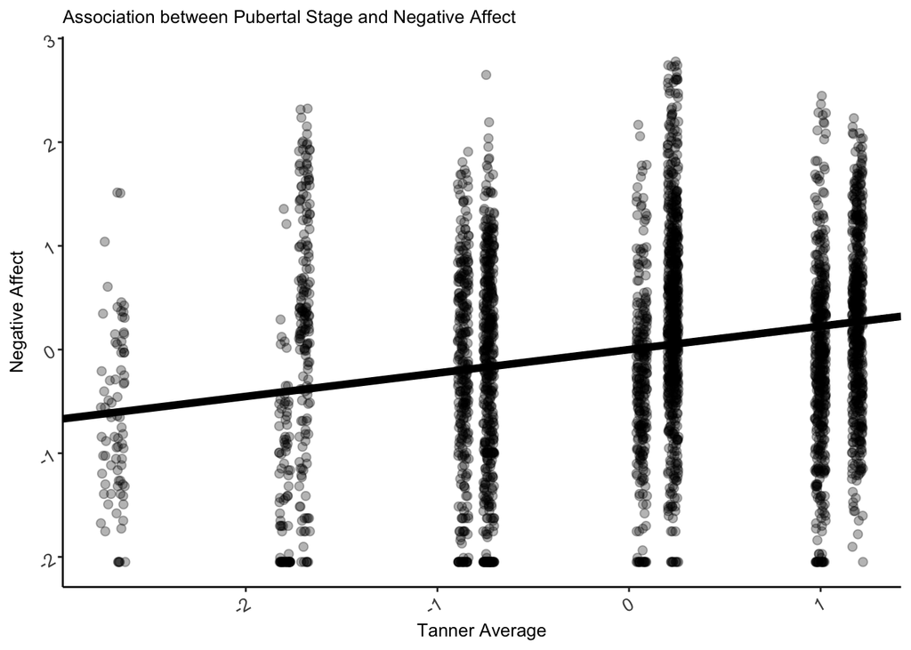

```r
tanint <- summary(m1)$coefficients[1,1] # fine to extract from the OLS bc reg coefs don't change (just the SEs)
tanslp <- summary(m1)$coefficients[2,1]

mw_merge_cent %>%
  ggplot(
    aes(
      x = tanner_average_for_mw_z,
      y = scale(neg_total_sqrt)
    )
  ) +
  geom_jitter(size = 2, alpha = .3) +
  geom_abline(
    intercept = tanint,
    slope = tanslp,
    size = 2
    )+
  theme_classic() +
  labs(
    x = "Tanner Average",
    y = "Negative Affect",
    title = "Association between Pubertal Stage and Negative Affect"
  ) +
  theme(
    axis.text = element_text(size = 10, angle = 30, hjust = 1),
    axis.title = element_text(size = 10),
    plot.title = element_text(size = 10)
  )
```